# Air Quality Training

West of England Mayoral Combined Authority

Steve Crawshaw

Analysis Team

## Purpose

- Improving understanding of air quality in MCA and UAs
- Enabling compliance with air quality legislation
- Protecting public health

## Content

- Air Quality: Introduction
- Health and Environmental Impacts
- Regulatory Framework
- Air Quality Monitoring and Management in Transport Schemes
- Risk Assessment and Mitigation

## Air Quality: Introduction

- Pollutants
- Sources
- History

## Pollutants

- Nitrogen oxides (NOx) - a group of gases that includes NO<sub>2</sub> and nitric oxide (NO) - complex atmospheric chemistry creates..
- Nitrogen dioxide (NO<sub>2</sub>) - an acidic gas that irritates the lungs
- Particulate matter (PM<sub>10</sub> and PM<sub>2.5</sub>) - tiny particles that can penetrate deep into the lungs
- Ozone (O<sub>3</sub>) - a reactive gas that can cause respiratory problems
- Volatile organic compounds (VOCs) - important ozone precursors

## Sources of Air Pollution

[figure not shown]

## Sources and Exposure (NOx)

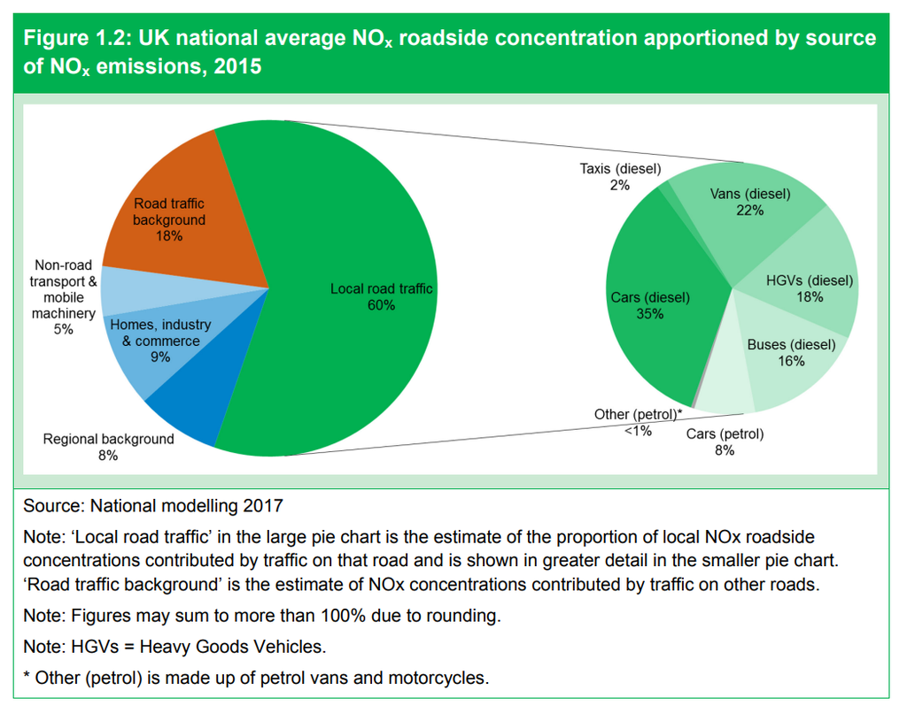

## Sources and Exposure (PM)

- Transport accounts for 21% of PM<sub>2.5</sub> and 18% of PM<sub>10</sub>
- 20% of PM<sub>2.5</sub> emissions from domestic solid fuel
  - i.e. where people live
  - almost all discretionary emissions
  - 36% increase in PM from this source 2009 - 2020

## Indoor pollution

- Indoor pollution is significant but less regulated than outdoor
- Cooking (gas) - NO<sub>2</sub>
- Heating (solid fuel) - PM<sub>2.5</sub>
- Off - gassing (furniture, carpets, paint) - VOCs
- Transport (and other) emissions ingress from outside